# COGS 536 Recitation - 30 December

Burcu

- **Week 2:** factorial ANOVA + within-subject ANOVA (2–3 way) + mixed ANOVA (between + within) + follow-ups.

# 1 2 — Factorial, Within-Subject (2–3 way), and Mixed ANOVA

## 1.1 9. Factorial (two-way between-subject) ANOVA

### 1.1.1 Example: Alcohol × Gender → Attractiveness rating

```r
set.seed(2)

alcohol <- expand.grid(
  Alcohol = factor(c("None", "2pints", "4pints"), levels = c("None", "2pints", "4pints")),
  Gender  = factor(c("Female", "Male"), levels = c("Female", "Male")),
  rep     = 1:18
)

# Simulate an interaction: alcohol affects males more negatively at 4pints
base <- 60
alcohol$Rating <- with(alcohol,
  base +
    ifelse(Gender == "Female", 2, -2) +
    ifelse(Alcohol == "None", 0, ifelse(Alcohol == "2pints", 2, -8)) +
    ifelse(Gender == "Male" & Alcohol == "4pints", -10, 0) +
    rnorm(nrow(alcohol), 0, 6)
)

alcohol <- alcohol[, c("Alcohol","Gender","Rating")]
head(alcohol)
```

```
##   Alcohol Gender   Rating
## 1    None Female 56.61851
## 2  2pints Female 65.10910
## 3  4pints Female 63.52707
## 4    None   Male 51.21775
## 5  2pints   Male 59.51849
## 6  4pints   Male 40.79452
```

### 1.1.2 Fit two-way ANOVA with interaction

```r
m_2way <- aov(Rating ~ Alcohol * Gender, data = alcohol)
summary(m_2way)
```

```
##                 Df Sum Sq Mean Sq F value   Pr(>F)
## Alcohol          2   3673  1836.6  37.151 7.58e-13 ***
## Gender           1   1276  1275.6  25.804 1.71e-06 ***
## Alcohol:Gender   2    741   370.5   7.494 0.000919 ***
## Residuals      102   5042    49.4
## ---
## Signif. codes:  0 '***' 0.001 '**' 0.01 '*' 0.05 '.' 0.1 ' ' 1
```

### 1.1.3 Interaction plot

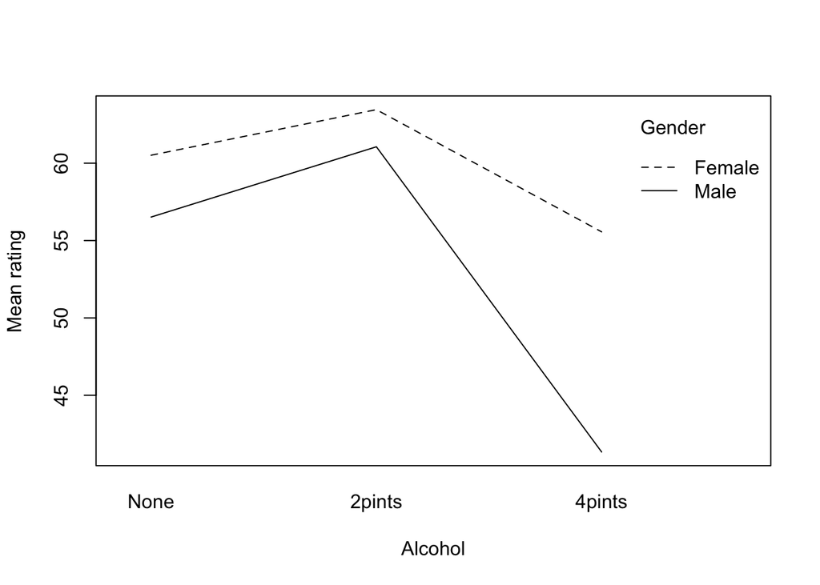

```r
interaction.plot(alcohol$Alcohol, alcohol$Gender, alcohol$Rating,
                 xlab = "Alcohol", ylab = "Mean rating", trace.label = "Gender")
```

### 1.1.4 Follow-ups if interaction is significant (simple comparisons)

```r
library(emmeans)
emm2 <- emmeans(m_2way, ~ Alcohol | Gender)
pairs(emm2, adjust = "bonferroni")
```

```
## Gender = Female:
##  contrast        estimate   SE  df t.ratio p.value
##  None - 2pints      -2.95 2.34 102  -1.258  0.6342
##  None - 4pints       4.95 2.34 102   2.113  0.1112
##  2pints - 4pints     7.90 2.34 102   3.370  0.0032
##
## Gender = Male:
##  contrast        estimate   SE  df t.ratio p.value
##  None - 2pints      -4.54 2.34 102  -1.939  0.1660
##  None - 4pints      15.18 2.34 102   6.477  <.0001
##  2pints - 4pints    19.72 2.34 102   8.416  <.0001
##
## P value adjustment: bonferroni method for 3 tests
```

## 1.2 10. Two-way within-subject ANOVA

### 1.2.1 Example D: Looks × Charisma (both within-subject)

We simulate a within-subject design with two within factors: - Looks: Attractive / Average / Ugly - Charisma: High / Some / None

```r
set.seed(3)

speed <- expand.grid(
  Subject  = factor(1:30),
  Looks    = factor(c("Attractive","Average","Ugly"),
                    levels = c("Attractive","Average","Ugly")),
  Charisma = factor(c("High","Some","None"),
                    levels = c("High","Some","None"))
)

# Simulate main effects + interaction-ish structure
speed$Rating <- with(speed,
  75 +
    ifelse(Looks == "Attractive", 10, ifelse(Looks == "Average", 0, -12)) +
    ifelse(Charisma == "High", 8, ifelse(Charisma == "Some", 0, -10)) +
    # small interaction: charisma matters less when looks are ugly
    ifelse(Looks == "Ugly" & Charisma == "High", -4, 0) +
    rnorm(nrow(speed), 0, 7)
)

head(speed)
```

```
##   Subject      Looks Charisma   Rating
## 1       1 Attractive     High 86.26647
## 2       2 Attractive     High 90.95232
## 3       3 Attractive     High 94.81152
## 4       4 Attractive     High 84.93508
## 5       5 Attractive     High 94.37048
## 6       6 Attractive     High 93.21087
```

### 1.2.2 Fit two-way within-subject ANOVA with `aov()` + `Error()`

```r
m_within2 <- aov(Rating ~ Looks * Charisma + Error(Subject/(Looks*Charisma)), data = speed)
summary(m_within2)
```

```
##
## Error: Subject
##           Df Sum Sq Mean Sq F value Pr(>F)
## Residuals 29   1744   60.15
##
## Error: Subject:Looks
##           Df Sum Sq Mean Sq F value Pr(>F)
## Looks      2  18930    9465   188.3 <2e-16 ***
## Residuals 58   2915      50
## ---
## Signif. codes:  0 '***' 0.001 '**' 0.01 '*' 0.05 '.' 0.1 ' ' 1
##
## Error: Subject:Charisma
##           Df Sum Sq Mean Sq F value Pr(>F)
## Charisma   2  12328    6164   127.4 <2e-16 ***
## Residuals 58   2806      48
## ---
## Signif. codes:  0 '***' 0.001 '**' 0.01 '*' 0.05 '.' 0.1 ' ' 1
##
## Error: Subject:Looks:Charisma
##                 Df Sum Sq Mean Sq F value Pr(>F)
## Looks:Charisma   4    339   84.82   1.883  0.118
## Residuals      116   5224   45.03
```

## 1.3 11. Three-way mixed ANOVA (one between + two within)

### 1.3.1 Example E: Add Gender as between-subject factor to Speed Dating

```r
set.seed(4)

# Add a between-subject variable (Gender) at the subject level
subj_gender <- data.frame(
  Subject = factor(1:30),
  Gender  = factor(rep(c("Female","Male"), each = 15), levels = c("Female","Male"))
)

speed_mixed <- merge(speed, subj_gender, by = "Subject")

# Slightly modify ratings: gender difference depends on looks (toy pattern)
speed_mixed$Rating2 <- with(speed_mixed,
  Rating +
    ifelse(Gender == "Female" & Looks == "Attractive", 2, 0) +
    ifelse(Gender == "Male" & Looks == "Ugly", -2, 0)
)

head(speed_mixed)
```

```
##   Subject      Looks Charisma   Rating Gender  Rating2
## 1       1 Attractive     High 86.26647 Female 88.26647
## 2       1    Average     Some 64.53206 Female 64.53206
## 3       1       Ugly     None 51.07867 Female 51.07867
## 4       1       Ugly     High 71.01463 Female 71.01463
## 5       1    Average     High 89.30437 Female 89.30437
## 6       1       Ugly     Some 53.96055 Female 53.96055
```

### 1.3.2 Mixed ANOVA via `aov()`

```r
m_mixed3 <- aov(Rating2 ~ Gender * Looks * Charisma + Error(Subject/(Looks*Charisma)), data = speed_mixed)
summary(m_mixed3)
```

```
##
## Error: Subject
##           Df Sum Sq Mean Sq F value  Pr(>F)
## Gender     1   1256  1256.2   30.73 6.3e-06 ***
## Residuals 28   1145    40.9
## ---
## Signif. codes:  0 '***' 0.001 '**' 0.01 '*' 0.05 '.' 0.1 ' ' 1
##
## Error: Subject:Looks
##              Df Sum Sq Mean Sq F value Pr(>F)
## Looks         2  22798   11399 221.026 <2e-16 ***
## Gender:Looks  2     24      12   0.237   0.79
## Residuals    56   2888      52
## ---
## Signif. codes:  0 '***' 0.001 '**' 0.01 '*' 0.05 '.' 0.1 ' ' 1
##
## Error: Subject:Charisma
##                 Df Sum Sq Mean Sq F value Pr(>F)
## Charisma         2  12328    6164 125.519 <2e-16 ***
## Gender:Charisma  2     56      28   0.567   0.57
## Residuals       56   2750      49
## ---
## Signif. codes:  0 '***' 0.001 '**' 0.01 '*' 0.05 '.' 0.1 ' ' 1
##
## Error: Subject:Looks:Charisma
##                        Df Sum Sq Mean Sq F value Pr(>F)
## Looks:Charisma          4    339   84.82   1.876  0.120
## Gender:Looks:Charisma   4    161   40.18   0.889  0.473
## Residuals             112   5063   45.21
```

### 1.3.3 Follow-up strategy

**Rule of thumb:** interpret in this order

1. Three-way interaction (Gender × Looks × Charisma)
2. Two-way interactions
3. Main effects (only if higher-order interactions are not meaningful)

#### 1.3.3.1 Example follow-up: simple effects of Looks within each Gender (collapsed over Charisma)

```r
emm_mixed <- emmeans(aov(Rating2 ~ Gender * Looks * Charisma, data = speed_mixed),
                     ~ Looks | Gender)
pairs(emm_mixed, adjust = "holm")
```

```
## Gender = Female:
##  contrast             estimate   SE  df t.ratio p.value
##  Attractive - Average     10.7 1.45 252   7.408  <.0001
##  Attractive - Ugly        22.0 1.45 252  15.222  <.0001
##  Average - Ugly           11.3 1.45 252   7.814  <.0001
##
## Gender = Male:
##  contrast             estimate   SE  df t.ratio p.value
##  Attractive - Average     10.2 1.45 252   7.085  <.0001
##  Attractive - Ugly        23.0 1.45 252  15.898  <.0001
##  Average - Ugly           12.7 1.45 252   8.813  <.0001
##
## Results are averaged over the levels of: Charisma
## P value adjustment: holm method for 3 tests
```

> Technical note: For follow-ups we often refit without `Error()` using a mixed-model workflow. For this course, it is acceptable to show follow-ups via `emmeans` on the fixed-effects model as a **teaching approximation**. If you want a fully correct repeated-measures follow-up pipeline, consider `afex::aov_ez()` or mixed-effects models (optional, not required).

## 1.4 12. Reporting templates (APA-style)

### 1.4.1 One-way between-subject ANOVA

> A one-way between-subjects ANOVA showed a significant effect of **Dose** on libido scores, *F*(2, 27) = …, *p* = …, indicating that libido differed across dose levels.

### 1.4.2 Two-way between-subject ANOVA

> A two-way ANOVA revealed a significant **Alcohol × Gender** interaction, *F*(2, …) = …, *p* = …, suggesting that the effect of alcohol on ratings differed by gender.

### 1.4.3 Repeated-measures ANOVA

> A one-way repeated-measures ANOVA showed a significant effect of **Condition** on scores, *F*(2, …) = …, *p* = … .

### 1.4.4 Friedman’s ANOVA

> Participants differed across conditions, χ²(2) = …, *p* = … .

# 2 Optional appendix — Extra examples to swap in

## 2.1 A. Use a real dataset (optional): `ToothGrowth` for one-way or two-way ANOVA

```r
data(ToothGrowth)
head(ToothGrowth)
```

```
##    len supp dose
## 1  4.2   VC  0.5
## 2 11.5   VC  0.5
## 3  7.3   VC  0.5
## 4  5.8   VC  0.5
## 5  6.4   VC  0.5
## 6 10.0   VC  0.5
```

```r
# One-way example (dose only)
ToothGrowth$dose_f <- factor(ToothGrowth$dose)
m_tg_1 <- aov(len ~ dose_f, data = ToothGrowth)
TukeyHSD(m_tg_1)
```

```
##   Tukey multiple comparisons of means
##     95% family-wise confidence level
##
## Fit: aov(formula = len ~ dose_f, data = ToothGrowth)
##
## $dose_f
##         diff       lwr       upr    p adj
## 1-0.5  9.130  5.901805 12.358195 0.00e+00
## 2-0.5 15.495 12.266805 18.723195 0.00e+00
## 2-1    6.365  3.136805  9.593195 4.25e-05
```

```r
# Two-way factorial (dose × supp)
m_tg_2 <- aov(len ~ dose * supp, data = ToothGrowth)
summary(m_tg_2)
```

```
##             Df Sum Sq Mean Sq F value   Pr(>F)
## dose         1 2224.3  2224.3 133.415  < 2e-16 ***
## supp         1  205.4   205.4  12.317 0.000894 ***
## dose:supp    1   88.9    88.9   5.333 0.024631 *
## Residuals   56  933.6    16.7
## ---
## Signif. codes:  0 '***' 0.001 '**' 0.01 '*' 0.05 '.' 0.1 ' ' 1
```

## 2.2 B. Quick reminder: ANOVA is part of the GLM family

- ANOVA can be seen as regression with categorical predictors.
- This helps later with correlation/regression weeks.